# Oyster ploidy field study survival analysis

Survival analysis to the end of 2023 for oyster ploidy project

## Read in the data and create basic tables and graphs

Load the required packages. Using survival package that was updated in August 2023

```r
library(tidyverse)
library(here)
library(survival)
library(ggfortify)
library(ggsurvfit)
library(survminer)
library(gridExtra)
library(frailtyEM)
```

Read in the mortality data from the field experiments

```r
survdat <- read.csv(here("Data", "MAY_OCT_2023_MORTSBYBAG.csv"))
```

## Data Wrangling

Correct the data structure

```r
survdat <- survdat %>% mutate_at(c("Site", "Bag_Col", "Month", "Bag_no", "Month_no"), as.factor)
str(survdat)
```

```
## 'data.frame':    576 obs. of  6 variables:
##  $ Site      : Factor w/ 4 levels "Chelsea","Hood Head",..: 1 1 1 1 1 1 1 1 1 1 ...
##  $ Bag_Col   : Factor w/ 3 levels "Blue","Green",..: 2 2 2 2 2 2 2 2 1 1 ...
##  $ Month     : Factor w/ 6 levels "August","July",..: 4 4 4 4 4 4 4 4 4 4 ...
##  $ Bag_no    : Factor w/ 75 levels "2","3","8","9",..: 45 54 66 67 70 56 55 7 20 22 ...
##  $ Mort_count: int  0 0 0 0 0 0 0 0 0 0 ...
##  $ Month_no  : Factor w/ 6 levels "5","6","7","8",..: 1 1 1 1 1 1 1 1 1 1 ...
```

Create a new data sheet that calculates the number of survivors at each sampling event (as opposed to the number of moralities)

| Site | Bag_Col | Bag_no | Month_survivor | No_survivors |
| --- | --- | --- | --- | --- |
| Chelsea | Green | 59 | April_survivors | 50 |
| Chelsea | Green | 59 | May_survivors | 50 |
| Chelsea | Green | 59 | June_survivors | 50 |
| Chelsea | Green | 59 | July_survivors | 50 |
| Chelsea | Green | 59 | August_survivors | 48 |
| Chelsea | Green | 59 | Sept_survivors | 27 |
| Chelsea | Green | 59 | Oct_survivors | 20 |
| Chelsea | Green | 70 | April_survivors | 50 |
| Chelsea | Green | 70 | May_survivors | 50 |
| Chelsea | Green | 70 | June_survivors | 50 |

[output cut: 662 more lines]

Double check that all bags are accounted for. There should be 8 bags per colour site per sampling event = 56 as of October 2023

| Site | Bag_Col | nbags |
| --- | --- | --- |
| Chelsea | Blue | 56 |
| Chelsea | Green | 56 |
| Chelsea | Red | 56 |
| Hood Head | Blue | 56 |
| Hood Head | Green | 56 |
| Hood Head | Red | 56 |
| Manchester | Blue | 56 |
| Manchester | Green | 56 |
| Manchester | Red | 56 |
| Thorndyke Bay | Blue | 56 |

[output cut: 2 more lines]

Sumarise the number of survivors per site per sampling event

| Site | Bag_Col | Month_survivor | meansurv | semsurv |
| --- | --- | --- | --- | --- |
| Chelsea | Blue | April_survivors | 50.000 | 0.0000000 |
| Chelsea | Blue | August_survivors | 36.250 | 2.2420494 |
| Chelsea | Blue | July_survivors | 49.500 | 0.3273268 |
| Chelsea | Blue | June_survivors | 49.875 | 0.1250000 |
| Chelsea | Blue | May_survivors | 50.000 | 0.0000000 |
| Chelsea | Blue | Oct_survivors | 21.750 | 2.8707266 |
| Chelsea | Blue | Sept_survivors | 28.875 | 2.5455669 |
| Chelsea | Green | April_survivors | 50.000 | 0.0000000 |
| Chelsea | Green | August_survivors | 43.125 | 1.7262418 |
| Chelsea | Green | July_survivors | 48.250 | 0.5900968 |

[output cut: 74 more lines]

Create a basic survival plot taht shows the number of survivors at each sampling event

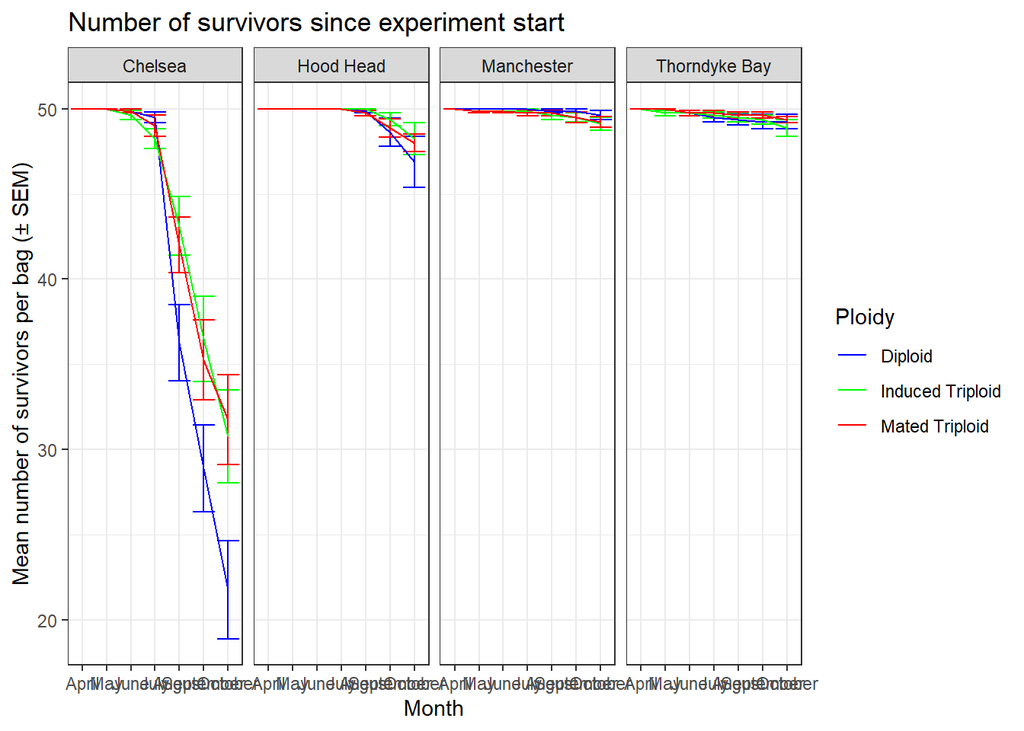

Need to turn the data into individual survival data. Each oyster should be listed with either alive or dead at each sampling point. Each oyster will need an ID number. 8 Cages per ploidy per site were monitored for mortality so a total of 400 oysters per ploidy per site at the start. Total of 4800 oysters.

This is a very clunky way to do this and needs to be streamlined - a for loop might work?

| Site.x | Bag_Col.x | Bag_no.x | OYS_ID | April_status | May_status | June_status | July_status | August_status | September_status | October_status |
| --- | --- | --- | --- | --- | --- | --- | --- | --- | --- | --- |
| Chelsea | Green | 59 | ChelseaGreen59_1 | 0 | 0 | 0 | 0 | 0 | 0 | 0 |
| Chelsea | Green | 59 | ChelseaGreen59_2 | 0 | 0 | 0 | 0 | 0 | 0 | 0 |
| Chelsea | Green | 59 | ChelseaGreen59_3 | 0 | 0 | 0 | 0 | 0 | 0 | 0 |
| Chelsea | Green | 59 | ChelseaGreen59_4 | 0 | 0 | 0 | 0 | 0 | 0 | 0 |
| Chelsea | Green | 59 | ChelseaGreen59_5 | 0 | 0 | 0 | 0 | 0 | 0 | 0 |
| Chelsea | Green | 59 | ChelseaGreen59_6 | 0 | 0 | 0 | 0 | 0 | 0 | 0 |
| Chelsea | Green | 59 | ChelseaGreen59_7 | 0 | 0 | 0 | 0 | 0 | 0 | 0 |
| Chelsea | Green | 59 | ChelseaGreen59_8 | 0 | 0 | 0 | 0 | 0 | 0 | 0 |
| Chelsea | Green | 59 | ChelseaGreen59_9 | 0 | 0 | 0 | 0 | 0 | 0 | 0 |
| Chelsea | Green | 59 | ChelseaGreen59_10 | 0 | 0 | 0 | 0 | 0 | 0 | 0 |

[output cut: 4790 more lines]

Pivot this data longer to get the correct formayt for survival analyses

## Survival analyses

### Survial plots for pooled data (no random effects of bag number)

Created Kaplan-Meyer survival plots for all data pooled across sites and ploidys. They do not consider the potential random effects of Bag within sites.

Create a survival plot faceted by Site

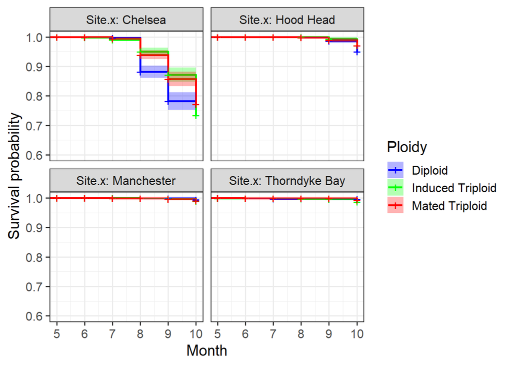

Create a survival plot faceted by ploidy

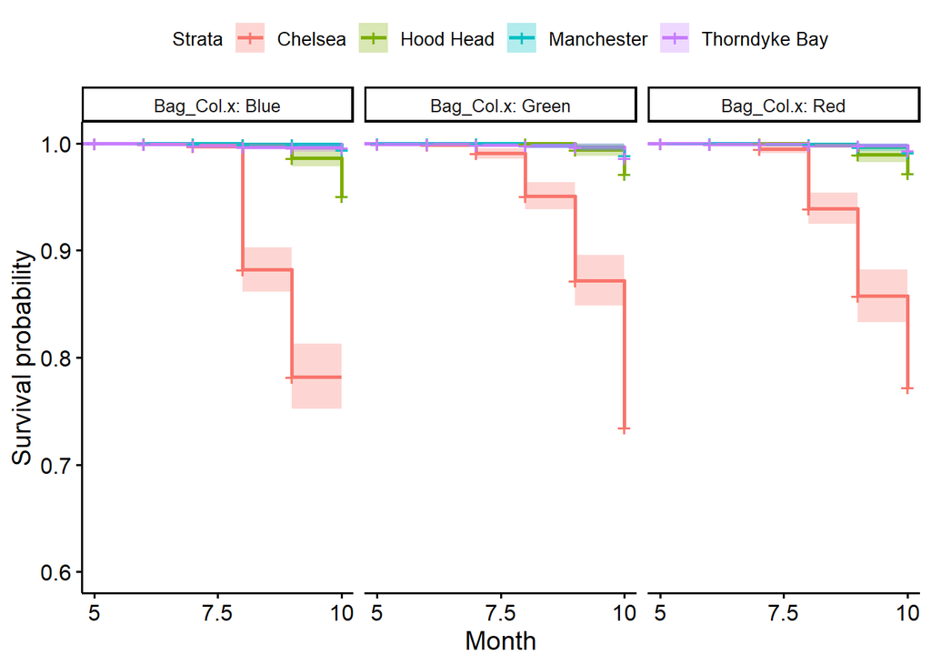

```r
pooled_ploidy_survplot <- survival_dat %>%
 ggsurvplot_facet(survfit(Surv(month_no, event, type = "right") ~ Site.x , data = .),
            facet.by = "Bag_Col.x",
            data = .,
            risk.table = FALSE, pval = FALSE, conf.int = TRUE,
            xlab = ("Month"),
            xlim = c(5, 10), ylim = c(0.6, 1))
pooled_ploidy_survplot
```

These plots show that there appeared to be an effect of site on survival throughout summer of 2023

Now I am going to create a cox proportional hazards model.

```
## Call:
## coxph(formula = Surv(month_no, event, type = "right") ~ Site.x *
##     Bag_Col.x, data = survival_dat)
##
##                                         coef exp(coef)  se(coef)       z
## Site.xHood Head                    -2.649772  0.070667  0.210860 -12.567
## Site.xManchester                   -4.792179  0.008294  0.581208  -8.245
## Site.xThorndyke Bay                -4.088149  0.016770  0.413686  -9.882
## Bag_Col.xGreen                     -0.585793  0.556664  0.104526  -5.604
## Bag_Col.xRed                       -0.620687  0.537575  0.106222  -5.843
## Site.xHood Head:Bag_Col.xGreen     -0.007074  0.992951  0.349790  -0.020
## Site.xManchester:Bag_Col.xGreen     1.440038  4.220857  0.697937   2.063
## Site.xThorndyke Bay:Bag_Col.xGreen  0.990437  2.692412  0.537312   1.843
## Site.xHood Head:Bag_Col.xRed        0.168624  1.183674  0.337315   0.500
## Site.xManchester:Bag_Col.xRed       1.319915  3.743104  0.715041   1.846
## Site.xThorndyke Bay:Bag_Col.xRed    0.432495  1.541098  0.614776   0.704
##                                           p
## Site.xHood Head                     < 2e-16
## Site.xManchester                    < 2e-16
## Site.xThorndyke Bay                 < 2e-16
## Bag_Col.xGreen                     2.09e-08
## Bag_Col.xRed                       5.12e-09
## Site.xHood Head:Bag_Col.xGreen       0.9839
## Site.xManchester:Bag_Col.xGreen      0.0391
## Site.xThorndyke Bay:Bag_Col.xGreen   0.0653
## Site.xHood Head:Bag_Col.xRed         0.6171
## Site.xManchester:Bag_Col.xRed        0.0649
## Site.xThorndyke Bay:Bag_Col.xRed     0.4817
##
## Likelihood ratio test=1327  on 11 df, p=< 2.2e-16
## n= 32852, number of events= 617
##    (748 observations deleted due to missingness)
```

### Include the random effects of cage

Following Paul’s example from the crab pH analyses I am going to use the frailtyEM package (@balan2019) to do a mixed effects analysis. I am including cage as a random effect because it acts as a grouping variable and we really don’t care that much about the impacts of cage in our interpretation.